# The River Ouse Project

# Examples of data analysis using extracts from the meadows database.

Specifically, using the data that can be downloaded in .csv format [from the app](https://sussexouse.shinyapps.io/meadows_db/). View the code here:

```r
# Libraries
library("RMySQL")
library(tidyverse)

# Functions
dbDisconnectAll <- function(){
  ile <- length(dbListConnections(MySQL())  )
  lapply( dbListConnections(MySQL()), function(x) dbDisconnect(x) )
  cat(sprintf("%s connection(s) closed.\n", ile))
}

GetTheData <-  function()
{
  # GET DATA FROM DB
  # Remote DB with password
  con <- dbConnect(MySQL(),
                   user  = "guest",
                   password    = "guest",
                   dbname="meadows",
                   port = 3306,
                   host   = "sxouse.ddns.net")


  q <- sprintf('select assembly_id, assembly_name, quadrat_count, nvc, quadrat_id, visit_date, records_id, species.species_id,
    species.species_name from assemblies
      join quadrats on quadrats.assembly_id = assemblies_id
      join visit_dates on quadrats.vd_id = visit_dates.vds_id
      join records on records.quadrat_id = quadrats_id
      join species on species.species_id = records.species_id
    # Two assemblies have 0 quadrat count; exclude A.capillaris_stolonifera,
    # and some odd assemblies with no assigned nvc
    where quadrat_count > 0 and species.species_id != 4 and nvc is not null;')
  # NOTE: this extract includes "MG5", i.e. some MG5 communities where the
  # team have not decided on a sub-group.

  rs1 = dbSendQuery(con, q)
  return(as_tibble(fetch(rs1, n=-1)))
  dbDisconnectAll()
}

########################## MAIN ##############################
# GET DATA FROM DB
the_data <- GetTheData()

# NVC standard species counts for comparison
stds <- tribble(
  ~nvc, ~std_cnts, ~low, ~high,
  "M10b",   37, 19, 56,
  "M23",   19, 6, 39,
  "M23a",   21, 6, 39,
  "M23b",   17, 8, 28,
  "M27b",   14, 6, 33,
  "M27c",   15, 9, 22,
  "M28b",   20, 10, 26,
  "MG10",   13, 6, 24,
  "MG10a",   12, 6, 20,
  "MG10b",   15, 8, 24,
  "MG13",   8, 3, 15,
  "MG1b",   12, 3, 18,
  "MG1c",   15, 4, 21,
  "MG1e",   21, 11, 30,
  "MG5",   23, 12, 38,
  "MG5a",   22, 13, 32,
  "MG5c",   22, 18, 27,
  "MG6a",   13, 9, 20,
  "MG6b",   14, 4, 26,
  "MG7b",   8, 4, 14,
  "MG7c",   11, 4, 19,
  "MG7d",   9, 3, 14,
  "MG8",   26, 15, 41,
  "MG9a",   15, 7, 36
)
```

to see the SQL query. Instructions about how to access the database using the phpMyAdmin interface can be found [here](https://zygodon.github.io/River-Ouse-Project-databases/).

## Species counts by quadrat and assembly.

Demonstrates using data downloaded from the database to construct boxplots showing species counts on a per-quadrat (sample) basis, or per uniform vegetation stand (assembly).

The published standards for species counts refer to counts in each quadrat (sample, in Rodwell’s terms). It is usual for at least five quadrats to be used in surveying a single stand, so we may ask, how does the count for single quadrats compare to the count for the stand as a whole? Compare the two boxplots; when aggregated by assembly, the species counts are higher than the standards - not surprisingly as a larger area (greater number of quadrats) is being sampled.

Does this give us a handle on questions of sampling efficiency, choice of quadrat size, and likely maximum species count?

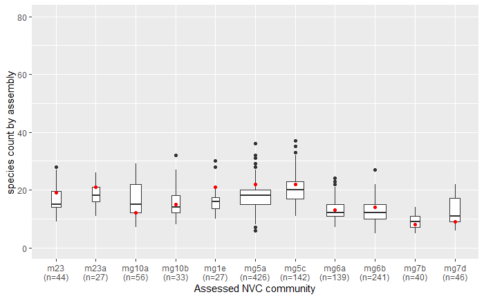

```r
# Count the number of quadrats of each community
# We may wish to limit the boxplot to communities with
# 5 or more samples (quadrats)
a <- (the_data
      %>% select(quadrat_id, nvc)
      %>% group_by(nvc)
      %>% summarise(nvc_cnt = n_distinct(quadrat_id)))

# Count the number of species in each sample (quadrat)
# This is what we are interested in making a boxplot for.
d <- (the_data %>% select(quadrat_id, nvc, species_name)
      %>% group_by(quadrat_id, nvc)
      %>% summarise(sp_cnt = n_distinct(species_name)))

# Left join and filter out communities with less than 20 examples
d <- left_join(d, a, by = "nvc")
d <- left_join(d, stds, by = "nvc") %>% filter(nvc_cnt > 19)

# Prepare xlab with the number of assemblies for each community
ns <- d %>% group_by(nvc) %>% distinct(nvc_cnt) %>% arrange(nvc)
x_labels <- paste(levels(as.factor(d$nvc)),"\n(n=",ns$nvc_cnt,")",sep="")

# Make the plot
g <- ggplot(d, aes(nvc,sp_cnt)) +
  coord_cartesian(ylim = c(0, 80)) +
  geom_boxplot(varwidth = T) +
  geom_point(y = d$std_cnts, colour = "red") +
  theme(legend.position = "none") +
  xlab("Assessed NVC community") +
  ylab("species count by assembly") +
  scale_x_discrete(labels = tolower(x_labels))
print(g)
```

Followed by species_counts by assembly:

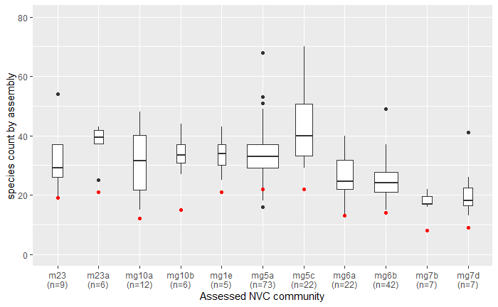

```r
# Boxplot: species counts for communities aggregated over assemblies;
# communities with fewer than 4 examples excluded.

# Count the number of assemblies in each community
# If there are only one or two, we won't want to include
# that community in the boxplot
a <- (the_data
      %>% select(assembly_id, nvc)
      %>% group_by(nvc)
      %>% summarise(nvc_cnt = n_distinct(assembly_id)))

# Count the number of species at each survey site (assembly)
# This is what we are interested in making a boxplot for.
d <- (the_data %>% select(assembly_id, nvc, species_name)
               %>% group_by(assembly_id, nvc)
               %>% summarise(sp_cnt = n_distinct(species_name)))

# Left join and filter out communities with less than 4 examples
d <- left_join(d, a, by = "nvc")
d <- left_join(d, stds, by = "nvc") %>% filter(nvc_cnt > 3)

# Prepare xlab with the number of assemblies for each community
ns <- d %>% group_by(nvc) %>% distinct(nvc_cnt) %>% arrange(nvc)
x_labels <- paste(levels(as.factor(d$nvc)),"\n(n=",ns$nvc_cnt,")",sep="")

# Make the plot
g <- ggplot(d, aes(nvc,sp_cnt)) +
  coord_cartesian(ylim = c(0, 80)) +
  geom_boxplot(varwidth = T) +
  geom_point(y = d$std_cnts, colour = "red") +
  theme(legend.position = "none") +
  xlab("Assessed NVC community") +
  ylab("species count by assembly") +
  scale_x_discrete(labels = tolower(x_labels))
print(g)
```